# Final Project DSA-8010

Saransh Rakshak

Due: December 10, 2024

```r
# Loading libraries for analysis
library(dplyr)
library(ggplot2)
library(tidyverse)
```

Give your answer as a short report that answers the key question and supports your answer using the data. Descriptive and inferential methods should be used. Make sure that every statistic, plot, or table that is included is also described in the text.

# 1. Fuji Apples

## Introduction

An agricultural research team in Idaho investigated the effect of Fuji apple trees’ branch configuration on the fruit produced by the trees. They planted 24 trees in an experimental orchard in three rows. Each row was treated to promote one of three branch configurations:

overlapped_arm

tipped_arm

tall_spindle

Each of the treatments (configurations) was applied to eight trees.

In the 2012 growing season, the trees’ fruit was harvested and the average weight per apple (grams) was recorded for each tree. The data are found in the file **fuji_apples.csv**. We will establish a significance level of $\alpha = 0.05$ for this analysis.

> Key question: Do the data suggest that the branch configuration affects the fruit weights?

```r
# Loading provided raw data
apples <- read.csv('data/fuji_apples.csv')

# Cleaning raw data
colnames(apples) <- c("index", "weight", "configuration")
apples$index <- apples$index - 1
rownames(apples) <- apples$index
apples <- subset(apples, select = -index)

# Explore dataframe
head(apples)
```

```
##     weight  configuration
## 0 211.3782 overlapped_arm
## 1 218.2755 overlapped_arm
## 2 182.5503 overlapped_arm
## 3 175.7907 overlapped_arm
## 4 141.6637 overlapped_arm
## 5 195.8015 overlapped_arm
```

```r
summary(apples)
```

```
##      weight      configuration
##  Min.   :141.7   Length:24
##  1st Qu.:185.4   Class :character
##  Median :214.8   Mode  :character
##  Mean   :232.8
##  3rd Qu.:281.7
##  Max.   :360.5
```

## Descriptive Statistics

To answer this question, we will first establish our null and alternative hypothesis. Our hypothesis will be as follows:

- *Null Hypothesis*: There is no difference in the mean fruit weights among the three branch configurations.

$$H_0: \mu_{1} = \mu_{2} =
\mu_{3}$$

- *Alternative Hypothesis*: At least one of the mean fruit weights differs from the others.

$H_A:$ At least one $\mu_{i}$ is different from the others, where $\mu_{i}$ represents the mean fruit weight for each configuration group.

```r
# Descriptive statistics
descriptive_stats <- apples %>%
  group_by(configuration) %>%
  summarise(
    mean_weight = mean(weight, na.rm = TRUE),
    sd_weight = sd(weight, na.rm = TRUE),
    min_weight = min(weight, na.rm = TRUE),
    max_weight = max(weight, na.rm = TRUE)
  )
print(descriptive_stats)
```

```
## # A tibble: 3 × 5
##   configuration  mean_weight sd_weight min_weight max_weight
##   <chr>                <dbl>     <dbl>      <dbl>      <dbl>
## 1 overlapped_arm        182.      28.2       142.       218.
## 2 tall_spindle          277.      65.5       184.       360.
## 3 tipped_arm            240.      41.5       176.       292.
```

1. Overlapped Arm
   - Mean Weight: The average fruit weight for the overlapped_arm treatment is 181.79 grams, which is the lowest among the three treatments.
   - Standard Deviation: The standard deviation is 28.23 grams, indicating moderate variability in the fruit weights for this treatment.
   - Range: The minimum fruit weight is 141.66 grams, and the maximum is 218.28 grams, giving a range of 76.62 grams. This range suggests that there is some variability in the fruit sizes but within a relatively narrower band compared to the other treatments.
2. Tall Spindle
   - Mean Weight: The tall_spindle treatment shows the highest average fruit weight at 276.73 grams. This suggests that this branch configuration results in the largest fruit on average.
   - Standard Deviation: The standard deviation is 65.53 grams, the highest among the three treatments. This higher variability indicates that fruit weights are more spread out in this treatment, with some trees likely producing significantly larger or smaller fruits than others
   - Range: The minimum weight for this treatment is 183.96 grams, and the maximum is 360.45 grams, giving a range of 176.49 grams. The larger range further confirms the higher variability in fruit weights for this treatment.
3. Tipped Arm
   - Mean Weight: The average fruit weight for the tipped_arm treatment is 239.98 grams, which is intermediate between the other two treatments.
   - The standard deviation is 41.52 grams, indicating moderate variability in the fruit weights, although less than the tall_spindle treatment.
   - The minimum fruit weight is 175.63 grams, and the maximum is 291.81 grams, resulting in a range of 116.18 grams, which is larger than the overlapped_arm range but smaller than the tall_spindle range.

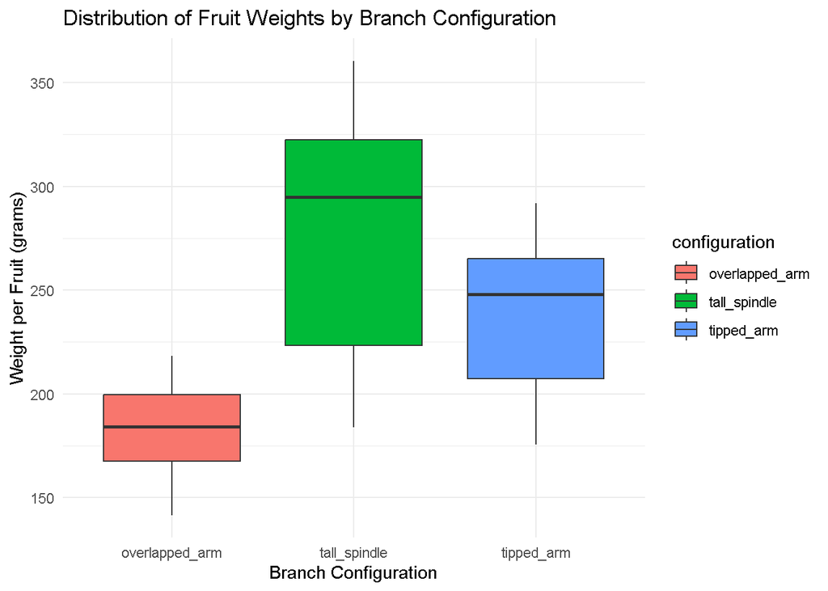

```r
ggplot(apples, aes(x = configuration, y = weight, fill = configuration)) +
  geom_boxplot() +
  theme_minimal() +
  labs(
    title = "Distribution of Fruit Weights by Branch Configuration",
    x = "Branch Configuration",
    y = "Weight per Fruit (grams)"
  ) +
  theme_minimal()
```

Plot Findings:

- The tall_spindle treatment results in the largest average fruit weight but also shows the highest variability in fruit sizes, indicating that the fruit size can vary considerably within this treatment.
- The overlapped_arm treatment yields the smallest fruit on average, with the least variability, suggesting more consistency in fruit size.
- The tipped_arm treatment falls between the other two in terms of both average fruit weight and variability, with a moderate range of fruit sizes.

Our boxplot suggest that branch configuration does affect fruit weights, with the tall_spindle configuration leading to the largest fruit on average, albeit with more variability. The overlapped_arm configuration results in smaller but more consistent fruit. The tipped_arm treatment provides a balance between the two extremes. These differences in mean fruit weight, variability, and range across the treatments suggest that branch configuration plays a significant role in determining the size of the fruit produced.

## Inferential Analysis

We will now use a ANOVA test to evaluate whether any differences in means are statistically significant across the configurations. First, we must make sure our data matches the assumptions made by the ANOVA Test.

Requirements of ANOVA Test:

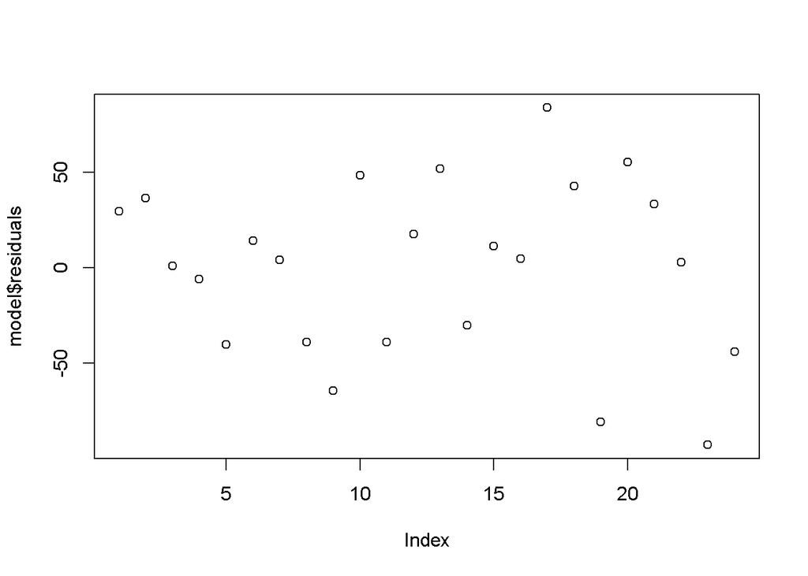

```r
model <- lm(weight ~ configuration, data = apples)

# independence - residual plot
plot(model$residuals)
```

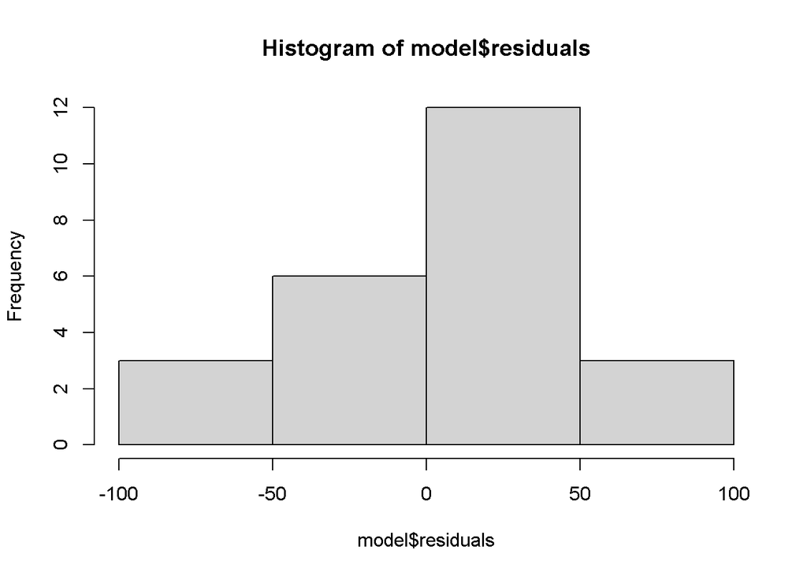

```r
# normality - histogram, QQ plot, shapiro-Wilk
hist(model$residuals)
```

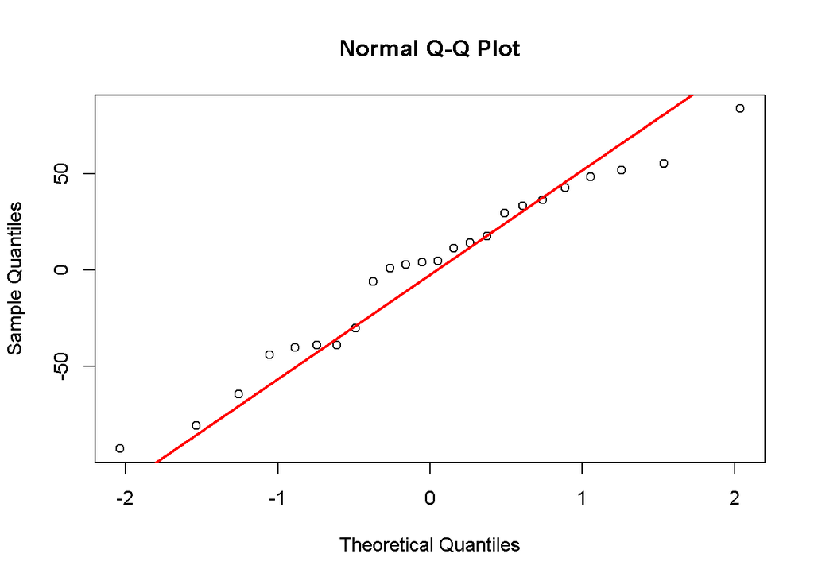

```r
qqnorm(model$residuals)
qqline(model$residuals, col = "red", lwd = 2)
```

```r
shapiro.test(model$residuals)
```

```
##
##  Shapiro-Wilk normality test
##
## data:  model$residuals
## W = 0.96985, p-value = 0.6632
```

The histogram of residuals appears approximately symmetric. The Q-Q plot indicates that the residuals closely follow a straight line, suggesting normality. The Shapiro-Wilk test has a p-value of 0.6632, which is greater than the typical alpha level of 0.05. This means we fail to reject the null hypothesis, supporting the assumption that the residuals are normally distributed. The residual plot against the index does not show any clear pattern, confirming the residuals are independent.

```r
anova_result <- aov(weight ~ configuration, data = apples)
summary(anova_result)
```

```
##               Df Sum Sq Mean Sq F value  Pr(>F)
## configuration  2  36668   18334   8.071 0.00251 **
## Residuals     21  47702    2272
## ---
## Signif. codes:  0 '***' 0.001 '**' 0.01 '*' 0.05 '.' 0.1 ' ' 1
```

The ANOVA test evaluates whether any differences in means are statistically significant across the groups. The ANOVA results show an F-value = 8.071 and p-value = 0.00251, which is less than the significance level ($\alpha$ = 0.05). This indicates a significant difference in fruit weights among the branch configurations. Since the null hypothesis (no difference in group means) is rejected, we will perform a post-hoc Tukey test to identify which specific configurations differ from one another.

```r
post_hoc <- TukeyHSD(anova_result)
print(post_hoc)
```

```
##   Tukey multiple comparisons of means
##     95% family-wise confidence level
##
## Fit: aov(formula = weight ~ configuration, data = apples)
##
## $configuration
##                                  diff        lwr       upr     p adj
## tall_spindle-overlapped_arm  94.93935  34.873543 155.00515 0.0018721
## tipped_arm-overlapped_arm    58.19761  -1.868195 118.26341 0.0586586
## tipped_arm-tall_spindle     -36.74174 -96.807543  23.32407 0.2924339
```

The columns for our post-hoc Tukey test are as follows:

- *diff* : The difference in means between the two configurations being compared.
- *lwr*, *upr* : The lower and upper bounds of the 95% confidence interval for the difference in means.
- *p adj* : The adjusted p-value, which accounts for multiple comparisons. This tells you whether the difference is statistically significant after adjusting for the fact that multiple comparisons are being made.

## Conclusion

*tall_spindle* vs. *overlapped_arm*

- Difference in means: 94.94 grams.
- Confidence interval: The confidence interval for the difference is between 34.87 and 155.01 grams. Since this interval does not include 0, it suggests **there is significant difference** between the two configurations.
- Adjusted p-value: 0.00187, which is less than 0.05, indicating **there is significant difference** between the means of tall spindle and overlapped arm.

*tipped_arm* vs. *overlapped_arm*

- Difference in means: 58.20 grams.
- Confidence interval: The confidence interval for the difference is between −1.87 and 118.26 grams. Since 0 is within this interval, this suggests that the **difference is not statistically significant**.
- Adjusted p-value: 0.0587, which is just above 0.05, suggesting the **difference is not statistically significant** at the 5% significance level.

*tipped_arm* vs. *tall_spindle*

- Difference in means: −36.74 grams.
- Confidence interval: The confidence interval for the difference is between −96.81 and 23.32 grams. Since 0 is within this interval, this suggests that the **difference is not statistically significant**.
- Adjusted p-value: 0.2924, which is greater than 0.05, indicating that the **difference is not statistically significant**.

**Thus we can conclude that…**

> ✴️ Branch configuration plays a significant role in determining the size of the fruit produced.

> ✴️ There is a significant difference in the mean fruit weights between the *tall_spindle* and *overlapped_arm* configurations.

> ✴️ There is no significant difference between *tipped_arm* and *overlapped_arm*, and between *tipped_arm* and *tall_spindle*.

Our analysis using this dataset is flawed for the following reasons:

```
- Limited Sample Size: With only 24 trees, the sample size may be too small to generalize the results to a larger population of Fuji apple trees or to account for variability in tree growth and fruit production.

- Lack of Randomization: If the three rows were not randomized or if the rows are inherently different (e.g., due to soil quality, sunlight exposure, or irrigation patterns), this could introduce bias into the results. Row effects might confound the observed effects of the branch configurations.

- Variability in Tree Growth: The trees' growth might vary due to genetic differences or differences in initial planting conditions, which are unrelated to the branch configuration treatment. Environmental factors like soil fertility, water availability, or pest pressure could vary across the rows, influencing apple weight independently of branch configuration. This variability could introduce noise into the data, making it harder to detect treatment effects.

- Statistical Inconsistancies: The analysis focuses solely on average apple weight. Other important factors, such as total yield per tree, fruit quality, or marketability, are not considered, thus the overall effect on productivity or profitability might not be fully captured. The proximity of the trees within rows could lead to spatial autocorrelation (e.g., nearby trees experiencing similar conditions), violating the assumption of independence in many statistical analyses. This could inflate Type I error rates or bias the estimation of treatment effects.
```

These could be mitigated by doing the following:

```
- Increase the Sample Size: Include more trees to improve statistical power.

- Randomize Treatments: Randomly assign branch configurations within and across rows.

- Control for Confounders: Measure and account for environmental factors like soil quality or sunlight exposure.

- Repeat Over Multiple Seasons: Extend the study to observe consistency across years.

- Measure Additional Outcomes: Consider total yield, fruit quality, or profitability to complement average weight analysis.
```

# 2. Maryland Crashes

## Introduction

The dataset **crash_maryland.csv** contains records of vehicle crashes in Montgomery County, Maryland for which police reports were filed between 2015 and 2023. The posted data reflects a subset of all crashes: those that occurred during rain, snow, or sleet.

A team of government officials is looking to better understand conditions under which serious traffic accidents occur. One question they are interested in is whether the type of precipitation is related to increased chance of injury. This question is related to the variables *Weather* and *Injury.Severity*. We will establish a significance level of $\alpha = 0.05$ for this analysis.

> Key question: Do the data suggest that the *Weather* condition is associated with *Injury.Severity*? Under which condition(s) are crashes more likely to occur?

```r
# Loading provided raw data
crash <- read.csv('data/maryland_crash.csv')

# Cleaning provided raw data
crash <- crash[!duplicated(crash), ] # remove duplicate rows

# Explore dataframe
head(crash)
```

```
##             Collision.Type Weather Surface.Condition          Light
## 1        SAME DIR REAR END RAINING               WET       DAYLIGHT
## 2 SAME DIRECTION SIDESWIPE RAINING               WET       DAYLIGHT
## 3        HEAD ON LEFT TURN RAINING               WET       DAYLIGHT
## 4 SAME DIRECTION LEFT TURN RAINING               WET       DAYLIGHT
## 5        SAME DIR REAR END RAINING               WET       DAYLIGHT
## 6        HEAD ON LEFT TURN RAINING               WET DARK LIGHTS ON
##   Driver.Substance.Abuse Driver.At.Fault    Injury.Severity
## 1          NONE DETECTED              No NO APPARENT INJURY
## 2          NONE DETECTED              No NO APPARENT INJURY
## 3          NONE DETECTED              No NO APPARENT INJURY
## 4          NONE DETECTED             Yes NO APPARENT INJURY
## 5          NONE DETECTED             Yes NO APPARENT INJURY
## 6          NONE DETECTED             Yes NO APPARENT INJURY
##   Drivers.License.State Vehicle.Damage.Extent Vehicle.First.Impact.Location
## 1                    MD            FUNCTIONAL                    SIX OCLOCK
## 2                    MD            FUNCTIONAL                    ONE OCLOCK
## 3                    MD            FUNCTIONAL                 TWELVE OCLOCK
## 4                    MD           SUPERFICIAL                  SEVEN OCLOCK
## 5                    MD             DISABLING                 TWELVE OCLOCK
## 6                    MD             DISABLING                    ONE OCLOCK
##        Vehicle.Body.Type Speed.Limit
## 1          PASSENGER CAR          35
## 2          PASSENGER CAR          40
## 3          PASSENGER CAR          35
## 4 FIRE VEHICLE/EMERGENCY          35
## 5          PASSENGER CAR          30
## 6           PICKUP TRUCK          30
```

## Descriptive Statistics

To answer this question, we will first establish our null and alternative hypothesis. Our hypothesis for answering the question “Do the data suggest that the *Weather* condition is associated with *Injury.Severity*?” will be as follows:

- *Null Hypothesis*: The *Weather* condition is not associated with *Injury.Severity*.

$$H_0: P(Injury.Severity ∣ Weather) =
P(Injury.Severity)$$

- *Alternative Hypothesis*: There is an association between *Weather* condition and *Injury.Severity*.

$$H_A: P(Injury.Severity ∣ Weather)\neq
P(Injury.Severity)$$

We would also like to know “Under which condition(s) are crashes more likely to occur?”. To find this, we can analyze crash frequencies across *Weather* conditions using descriptive statistics and visualization. For example:

$P(Crash | Rain) > P(Crash | Other Weather Conditions)$

could be tested using pairwise comparisons of crash frequencies.

```r
# Descriptive analysis
contingency_table <- table(crash$Weather, crash$Injury.Severity)
print(contingency_table)
```

```
##
##           NO APPARENT INJURY SUSPECTED INJURY
##   RAINING                421              106
##   SLEET                   21                8
##   SNOW                    37                5
```

```r
prop_table <- prop.table(contingency_table, margin = 1)
print(round(prop_table, 2))
```

```
##
##           NO APPARENT INJURY SUSPECTED INJURY
##   RAINING               0.80             0.20
##   SLEET                 0.72             0.28
##   SNOW                  0.88             0.12
```

[figure not shown]

```r
crash_table <- data.frame(
  Weather = rep(c("RAINING", "SLEET", "SNOW"), each = 2),
  Injury.Severity = rep(c("NO APPARENT INJURY", "SUSPECTED INJURY"), times = 3),
  Count = c(461, 107, 21, 8, 37, 5)
)

ggplot(crash_table, aes(x = Weather, y = Count, fill = Injury.Severity)) +
  geom_bar(stat = "identity", position = "dodge") +
  labs(
    title = "Crash Counts by Weather Condition and Injury Severity",
    x = "Weather Condition",
    y = "Count of Crashes",
    fill = "Injury Severity"
  ) +
  theme_minimal()
```

In summary, rain is the most significant factor contributing to vehicle crashes in the dataset, making it the condition under which crashes are most likely to occur.

## Inferential Analysis

We would like to analyse the relation between *Weather* and *Injury.Severity*. Since both of these are categorical variables, we will use a Chi-Squared Test to evaluate whether the distribution of one categorical variable differs significantly across the levels of another. The chi-squared test does not rely on assumptions about the data’s distribution (like normality), making it suitable for categorical data. The test will also determine if the two variables are independent (null hypothesis) or if there is an association (alternative hypothesis).

- If the variables are independent, the proportion of Injury.Severity categories should be similar across all Weather conditions.
- If the variables are associated, the proportions of Injury.Severity will differ based on the Weather condition.

The p-value from the chi-squared test helps determine if the association is statistically significant:

- If the p-value is small (<0.05), it suggests that the observed differences are unlikely to be due to chance, indicating an association between Weather and Injury.Severity.
- If the p-value is large (>0.05), it suggests insufficient evidence to claim an association.

Correlation tests (like Pearson’s) are inappropriate because they require numerical data, and T-tests or ANOVA are unsuitable as they are used for comparing means of continuous variables.

```r
chi_sq_result <- chisq.test(contingency_table)
print(chi_sq_result)
```

```
##
##  Pearson's Chi-squared test
##
## data:  contingency_table
## X-squared = 2.7743, df = 2, p-value = 0.2498
```

Requirements of Chi-Squared Test:

1. Independence of Observations: Satisfied

```r
any(duplicated(crash))
```

```
## [1] FALSE
```

2. Adequate Sample Size: Satisfied, each cell in the contingency table has an expected frequency of at least 5.

```r
chi_sq_result$expected
```

```
##
##           NO APPARENT INJURY SUSPECTED INJURY
##   RAINING          422.12876       104.871237
##   SLEET             23.22910         5.770903
##   SNOW              33.64214         8.357860
```

## Conclusion

Results of our Chi-Squared test allow us to make the following analysis:

**Thus we conclude that…**

> ✴️ We fail to reject the null hypothesis ($H_0$), indicating that based on this analysis, there is no significant evidence to suggest that *Weather* conditions are associated with *Injury.Severity* in crashes. This implies that, based on this dataset, the *Weather* conditions (RAINING, SLEET, SNOW) do not appear to significantly influence the likelihood of *Injury.Severity* (NO APPARENT INJURY or SUSPECTED INJURY).

> ✴️ Rain is the most significant factor contributing to vehicle crashes in the dataset, making it the condition under which crashes are most likely to occur.

Issues with our data analysis due to our given data set arise as follows:

[output not shown]